# Unit Circle Definitions of Trigonometric Functions

# SOHCAHTOA Review

When you first learn right-triangle trigonometry, you use these definitions:

$$\sin(\theta)=\frac{\text{opp}}{\text{hyp}}$$
$$\cos(\theta)=\frac{\text{adj}}{\text{hyp}}$$
$$\tan(\theta)=\frac{\text{opp}}{\text{adj}}$$

[figure not shown]

# A right triangle with unit hypotenuse

If we draw a right triangle, with a hypotenuse with length 1, like in the drawing below, we can get some simpler definitions of the trigonometric functions. In fact, these definitions will be more useful too, because they allow a natural extension to obtuse and negative angles (or, really, this allows the angle to be any real number).

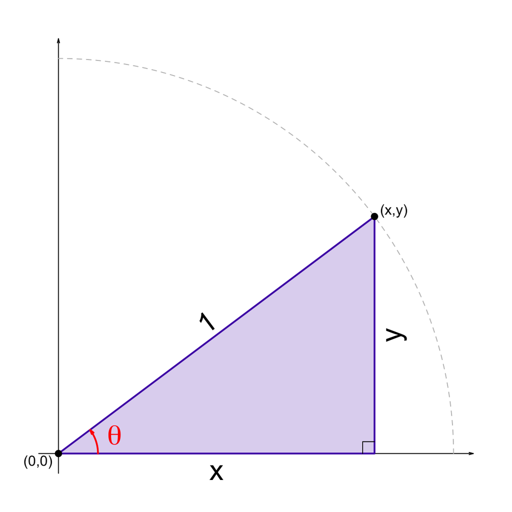

$$\sin(\theta)~=~\frac{y}{1}~=~y$$
$$\cos(\theta)~=~\frac{x}{1}~=~x$$
$$\tan(\theta)~=~\frac{y}{x}~=~\text{slope
from (0,0) to (x,y)}$$

# Example: $\theta=1.2$ radians

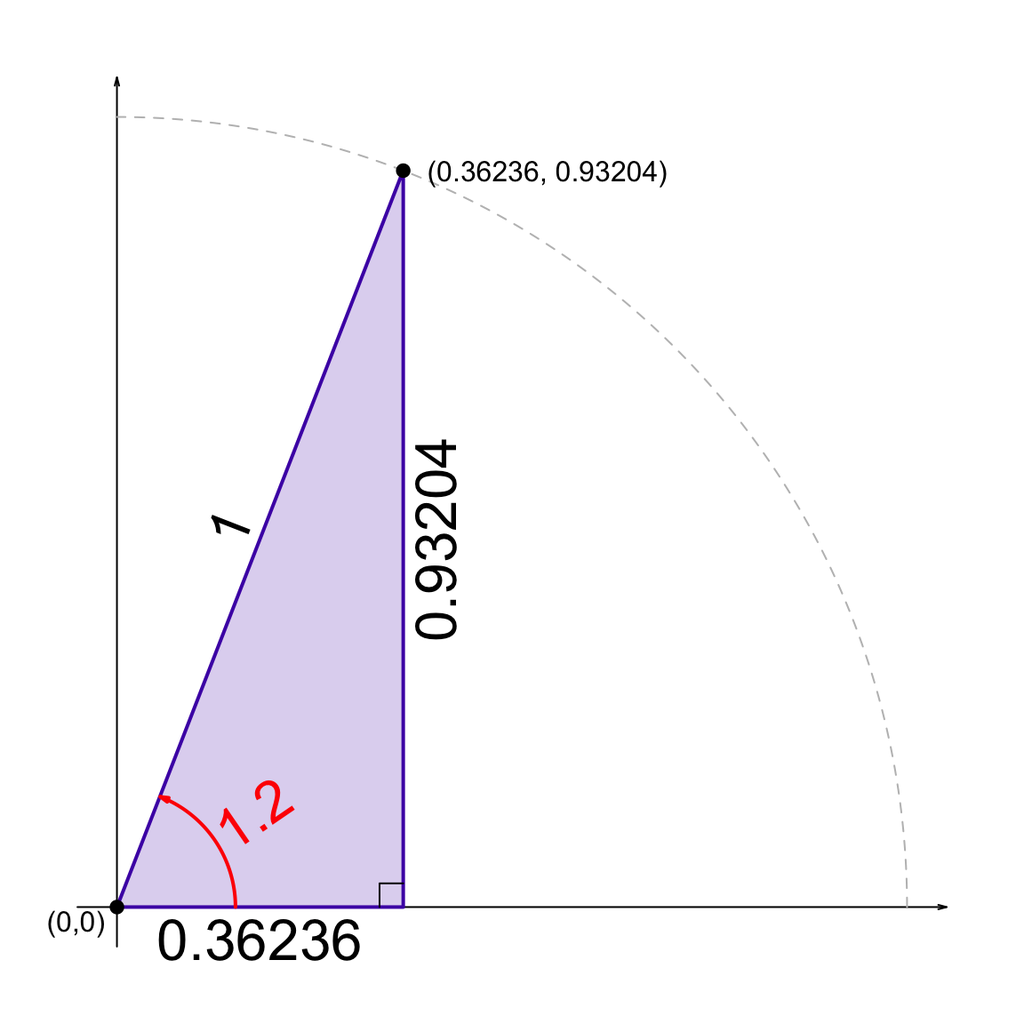

$$\sin(1.2)~=~0.93204$$
$$\cos(1.2)~=~0.36236$$
$$\tan(1.2)~=~ \frac{0.9320391}{0.3623578}
~=~2.57215$$

# Practice

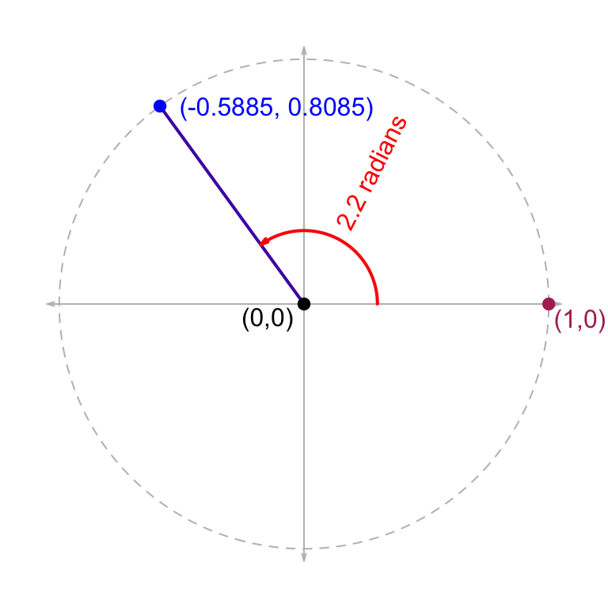

As shown above, on the unit circle, at an angle of $\theta=2.2$ radians, lies the point $(-0.5885,0.8085)$. Write the three trigonometric equations using the given angle and point.

- $\sin(2.2)~=~0.8085$
- $\cos(2.2)~=~-0.5885$
- $\tan(2.2)~=~\frac{0.8085}{-0.5885}~=~-1.37383$

# Practice 2

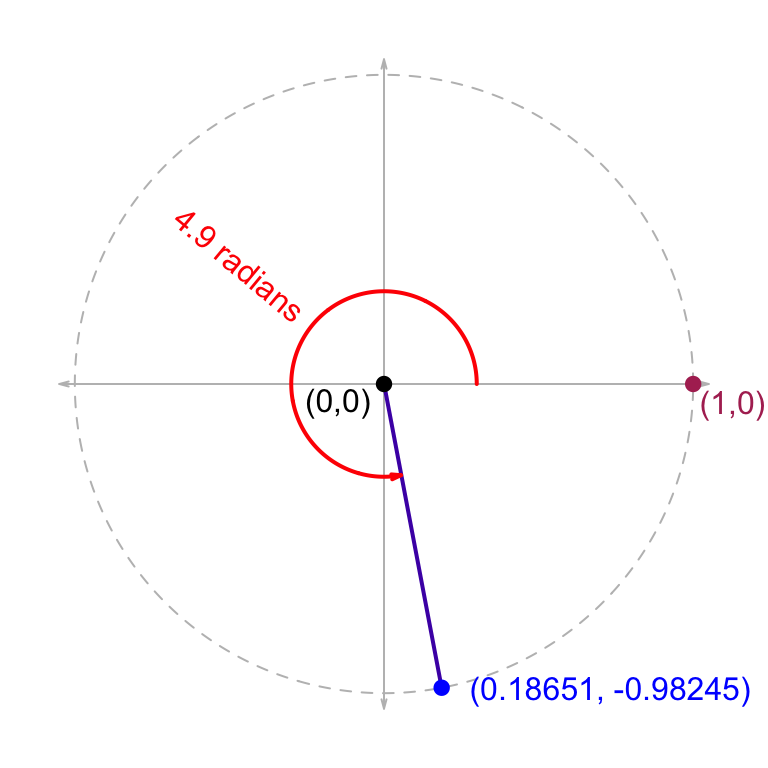

As shown above, on the unit circle, at an angle of $\theta=4.9$ radians, lies the point $(0.18651,-0.98245)$. Write the three trigonometric equations using the given angle and point.

- $\sin(4.9)~=~-0.98245$
- $\cos(4.9)~=~0.18651$
- $\tan(4.9)~=~\frac{-0.98245}{0.18651}~=~-5.26755$

# Practice 3

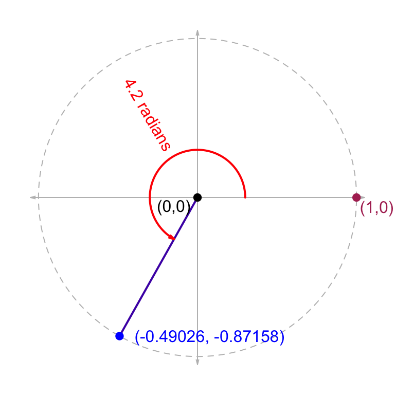

As shown above, on the unit circle, at an angle of $\theta=4.2$ radians, lies the point $(-0.49026,-0.87158)$. Write the three trigonometric equations using the given angle and point.

- $\sin(4.2)~=~-0.87158$
- $\cos(4.2)~=~-0.49026$
- $\tan(4.2)~=~\frac{-0.87158}{-0.49026}~=~1.77779$